# Exploratory Data Analysis Report

Report by dlookr package

2020-08-11

# 1 Introduction

The EDA Report provides exploratory data analysis information on objects that inherit data.frame and data.frame.

## 1.1 Information of Dataset

The dataset that generated the EDA Report is an **‘data.frame’** object. It consists of **400 observations** and **11 variables**.

## 1.2 Information of Variables

The variable information of the data set that generated the EDA Report is shown in the following table.:

Information of Variables

| variables | types | missing_count | missing_percent | unique_count | unique_rate |
| --- | --- | --- | --- | --- | --- |
| Sales | numeric | 0 | 0.0 | 336 | 0.8400 |
| CompPrice | numeric | 0 | 0.0 | 73 | 0.1825 |
| Income | numeric | 20 | 5.0 | 99 | 0.2475 |
| Advertising | numeric | 0 | 0.0 | 28 | 0.0700 |
| Population | numeric | 0 | 0.0 | 275 | 0.6875 |
| Price | numeric | 0 | 0.0 | 101 | 0.2525 |
| ShelveLoc | factor | 0 | 0.0 | 3 | 0.0075 |
| Age | numeric | 0 | 0.0 | 56 | 0.1400 |
| Education | numeric | 0 | 0.0 | 9 | 0.0225 |
| Urban | factor | 10 | 2.5 | 3 | 0.0075 |
| US | factor | 0 | 0.0 | 2 | 0.0050 |

The target variable of the data is **‘Sales’**, and the data type of the variable is **numeric**.

## 1.3 About EDA Report

EDA reports provide information and visualization results that support the EDA process. In particular, it provides a variety of information to understand the relationship between the target variable and the rest of the variables of interest.

# 2 Univariate Analysis

## 2.1 Descriptive Statistics

edaData  
11 Variables 400 Observations

Sales

| n | missing | distinct | Info | Mean | Gmd | .05 | .10 | .25 | .50 | .75 | .90 | .95 |
| --- | --- | --- | --- | --- | --- | --- | --- | --- | --- | --- | --- | --- |
| 400 | 0 | 336 | 1 | 7.496 | 3.192 | 3.149 | 4.119 | 5.390 | 7.490 | 9.320 | 11.300 | 12.442 |

lowest : 0.00 0.16 0.37 0.53 0.91 , highest: 13.91 14.37 14.90 15.63 16.27

CompPrice

| n | missing | distinct | Info | Mean | Gmd | .05 | .10 | .25 | .50 | .75 | .90 | .95 |
| --- | --- | --- | --- | --- | --- | --- | --- | --- | --- | --- | --- | --- |
| 400 | 0 | 73 | 0.999 | 125 | 17.3 | 98 | 106 | 115 | 125 | 135 | 145 | 150 |

lowest : 77 85 86 88 89 , highest: 157 159 161 162 175

Income

| n | missing | distinct | Info | Mean | Gmd | .05 | .10 | .25 | .50 | .75 | .90 | .95 |
| --- | --- | --- | --- | --- | --- | --- | --- | --- | --- | --- | --- | --- |
| 380 | 20 | 98 | 1 | 69.32 | 32.41 | 26.0 | 31.9 | 44.0 | 69.0 | 92.0 | 108.1 | 115.1 |

lowest : 21 22 23 24 25 , highest: 116 117 118 119 120

Advertising

| n | missing | distinct | Info | Mean | Gmd | .05 | .10 | .25 | .50 | .75 | .90 | .95 |
| --- | --- | --- | --- | --- | --- | --- | --- | --- | --- | --- | --- | --- |
| 400 | 0 | 28 | 0.952 | 6.635 | 7.337 | 0 | 0 | 0 | 5 | 12 | 16 | 19 |

lowest : 0 1 2 3 4 , highest: 23 24 25 26 29

Population

| n | missing | distinct | Info | Mean | Gmd | .05 | .10 | .25 | .50 | .75 | .90 | .95 |
| --- | --- | --- | --- | --- | --- | --- | --- | --- | --- | --- | --- | --- |
| 400 | 0 | 275 | 1 | 264.8 | 170.3 | 29.0 | 58.9 | 139.0 | 272.0 | 398.5 | 467.0 | 493.1 |

lowest : 10 12 13 14 16 , highest: 503 504 507 508 509

Price

| n | missing | distinct | Info | Mean | Gmd | .05 | .10 | .25 | .50 | .75 | .90 | .95 |
| --- | --- | --- | --- | --- | --- | --- | --- | --- | --- | --- | --- | --- |
| 400 | 0 | 101 | 1 | 115.8 | 26.52 | 77 | 87 | 100 | 117 | 131 | 146 | 155 |

lowest : 24 49 53 54 55 , highest: 166 171 173 185 191

ShelveLoc

| n | missing | distinct |
| --- | --- | --- |
| 400 | 0 | 3 |

```
 Value         Bad   Good Medium
 Frequency      96     85    219
 Proportion  0.240  0.212  0.547
```

Age

| n | missing | distinct | Info | Mean | Gmd | .05 | .10 | .25 | .50 | .75 | .90 | .95 |
| --- | --- | --- | --- | --- | --- | --- | --- | --- | --- | --- | --- | --- |
| 400 | 0 | 56 | 1 | 53.32 | 18.71 | 27.00 | 30.00 | 39.75 | 54.50 | 66.00 | 76.00 | 79.00 |

lowest : 25 26 27 28 29 , highest: 76 77 78 79 80

Education

| n | missing | distinct | Info | Mean | Gmd |
| --- | --- | --- | --- | --- | --- |
| 400 | 0 | 9 | 0.987 | 13.9 | 3.009 |

lowest : 10 11 12 13 14 , highest: 14 15 16 17 18

```
 Value         10    11    12    13    14    15    16    17    18
 Frequency     48    48    49    43    40    36    47    49    40
 Proportion 0.120 0.120 0.122 0.108 0.100 0.090 0.117 0.122 0.100
```

Urban

| n | missing | distinct |
| --- | --- | --- |
| 390 | 10 | 2 |

```
 Value         No   Yes
 Frequency    115   275
 Proportion 0.295 0.705
```

US

| n | missing | distinct |
| --- | --- | --- |
| 400 | 0 | 2 |

```
 Value         No   Yes
 Frequency    142   258
 Proportion 0.355 0.645
```

## 2.2 Normality Test of Numerical Variables

### 2.2.1 Statistics and Visualization of (Sample) Data

**[ CompPrice ]**

normality test : Shapiro-Wilk normality test

statistic : 0.99843, p-value : 0.977151

skewness and kurtosis

| type | skewness | kurtosis |
| --- | --- | --- |
| original | -0.0425941 | 3.026185 |
| log transformation | -0.4346631 | 3.367099 |
| sqrt transformation | -0.2347446 | 3.128007 |

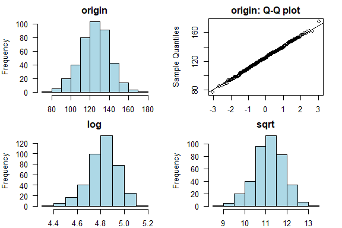

**[ Income ]**

normality test : Shapiro-Wilk normality test

```
 statistic : 0.96083,  p-value : 1.54872E-08
```

skewness and kurtosis

| type | skewness | kurtosis |
| --- | --- | --- |
| original | 0.0358759 | 1.895850 |
| log transformation | -0.5850148 | 2.294106 |
| sqrt transformation | -0.2636668 | 1.976451 |

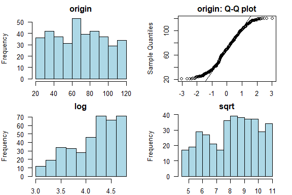

**[ Advertising ]**

normality test : Shapiro-Wilk normality test

```
 statistic : 0.87354,  p-value : 1.49183E-17
```

skewness and kurtosis

| type | skewness | kurtosis |
| --- | --- | --- |
| original | 0.6371848 | 2.446710 |
| log transformation | NaN | NaN |
| sqrt transformation | -0.0564511 | 1.465288 |

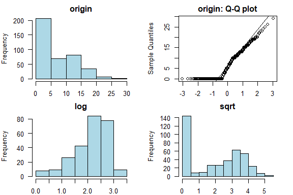

**[ Population ]**

normality test : Shapiro-Wilk normality test

```
 statistic : 0.95201,  p-value : 4.08085E-10
```

skewness and kurtosis

| type | skewness | kurtosis |
| --- | --- | --- |
| original | -0.0510343 | 1.797695 |
| log transformation | -1.2944747 | 4.133594 |
| sqrt transformation | -0.5426703 | 2.258393 |

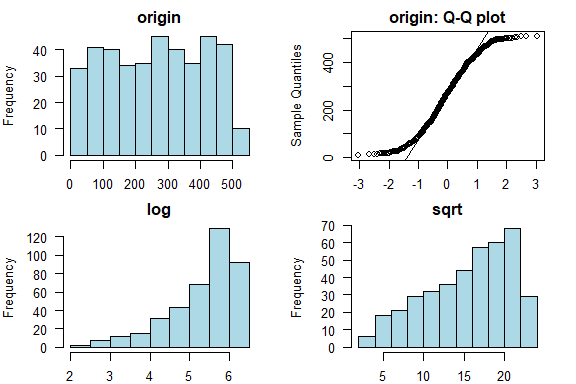

**[ Price ]**

normality test : Shapiro-Wilk normality test

```
 statistic : 0.99592,  p-value : 0.390213
```

skewness and kurtosis

| type | skewness | kurtosis |
| --- | --- | --- |
| original | -0.1248159 | 3.431294 |
| log transformation | -1.3588664 | 8.644789 |
| sqrt transformation | -0.6082760 | 4.588738 |

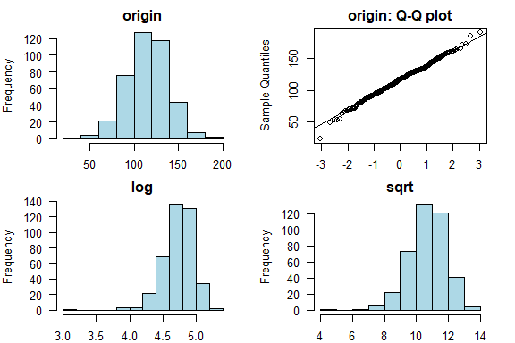

**[ Age ]**

normality test : Shapiro-Wilk normality test

```
 statistic : 0.95672,  p-value : 1.86455E-09
```

skewness and kurtosis

| type | skewness | kurtosis |
| --- | --- | --- |
| original | -0.0768920 | 1.864776 |
| log transformation | -0.5111921 | 2.171843 |
| sqrt transformation | -0.2889644 | 1.963116 |

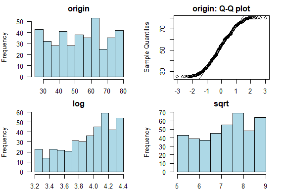

**[ Education ]**

normality test : Shapiro-Wilk normality test

```
 statistic : 0.9242,  p-value : 2.42693E-13
```

skewness and kurtosis

| type | skewness | kurtosis |
| --- | --- | --- |
| original | 0.0438416 | 1.702878 |
| log transformation | -0.1598795 | 1.743385 |
| sqrt transformation | -0.0571782 | 1.711755 |

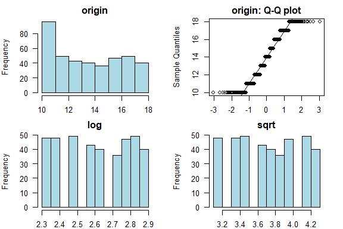

# 3 Relationship Between Variables

## 3.1 Correlation Coefficient

### 3.1.1 Correlation Coefficient by Variable Combination

Table of correlation coefficients (0.5 or more)

| Variable1 | Variable2 | Correlation Coefficient |
| --- | --- | --- |
| Price | CompPrice | 0.5848478 |

### 3.1.2 Correlation Plot of Numerical Variables

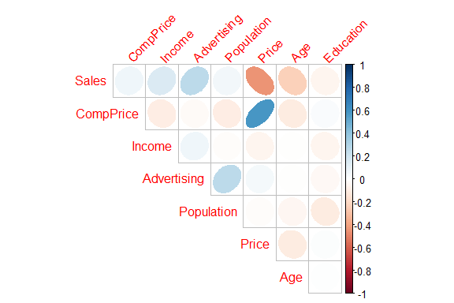

# 4 Target based Analysis

## 4.1 Grouped Descriptive Statistics

### 4.1.1 Grouped Numerical Variables

**[ CompPrice ]**

Simple Linear Model Information

Residual standard error: 3 on 398 degrees of freedom Multiple R-squared: 0.00411, Adjusted R-squared: 0.0016 F-statistic: 2 on 1 and 398 DF, p-value: 0.200939828941839

Coefficients:

Simple Linear Model coefficients : CompPrice

|  | Estimate | Std. Error | t value | Pr(>\|t\|) |
| --- | --- | --- | --- | --- |
| (Intercept) | 6.02 | 1.16 | 5.19 | 0.0 |
| CompPrice | 0.01 | 0.01 | 1.28 | 0.2 |

Visualization:

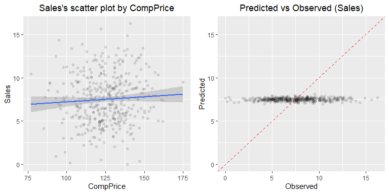

**[ Income ]**

Simple Linear Model Information

```
 Residual standard error: 3 on 378 degrees of freedom
 Multiple R-squared:  0.02346,  Adjusted R-squared:  0.02088
 F-statistic: 9 on 1 and 378 DF,  p-value: 0.00275705315131171
```

Coefficients:

Simple Linear Model coefficients : Income

|  | Estimate | Std. Error | t value | Pr(>\|t\|) |
| --- | --- | --- | --- | --- |
| (Intercept) | 6.42 | 0.39 | 16.57 | 0 |
| Income | 0.02 | 0.01 | 3.01 | 0 |

Visualization:

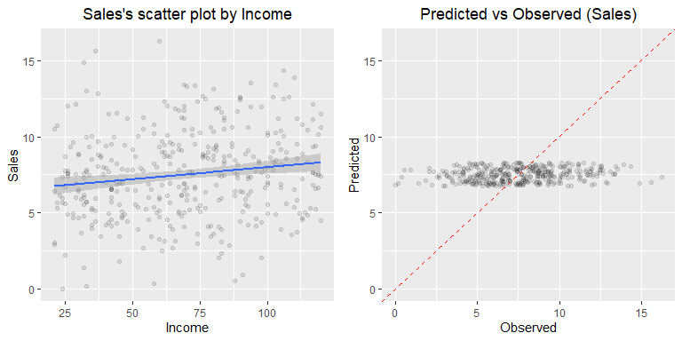

**[ Advertising ]**

Simple Linear Model Information

```
 Residual standard error: 3 on 398 degrees of freedom
 Multiple R-squared:  0.07263,  Adjusted R-squared:  0.0703
 F-statistic: 31 on 1 and 398 DF,  p-value: 4.37767711030276e-08
```

Coefficients:

Simple Linear Model coefficients : Advertising

|  | Estimate | Std. Error | t value | Pr(>\|t\|) |
| --- | --- | --- | --- | --- |
| (Intercept) | 6.74 | 0.19 | 35.01 | 0 |
| Advertising | 0.11 | 0.02 | 5.58 | 0 |

Visualization:

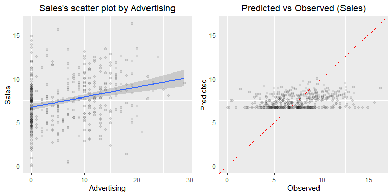

**[ Population ]**

Simple Linear Model Information

```
 Residual standard error: 3 on 398 degrees of freedom
 Multiple R-squared:  0.00255,  Adjusted R-squared:  4e-05
 F-statistic: 1 on 1 and 398 DF,  p-value: 0.313981609319049
```

Coefficients:

Simple Linear Model coefficients : Population

|  | Estimate | Std. Error | t value | Pr(>\|t\|) |
| --- | --- | --- | --- | --- |
| (Intercept) | 7.24 | 0.29 | 24.91 | 0.00 |
| Population | 0.00 | 0.00 | 1.01 | 0.31 |

Visualization:

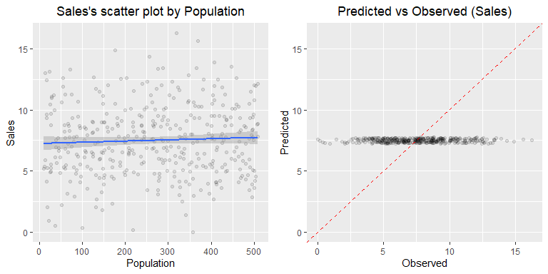

**[ Price ]**

Simple Linear Model Information

```
 Residual standard error: 3 on 398 degrees of freedom
 Multiple R-squared:  0.19798,  Adjusted R-squared:  0.19597
 F-statistic: 98 on 1 and 398 DF,  p-value: 7.61818701191278e-21
```

Coefficients:

Simple Linear Model coefficients : Price

|  | Estimate | Std. Error | t value | Pr(>\|t\|) |
| --- | --- | --- | --- | --- |
| (Intercept) | 13.64 | 0.63 | 21.56 | 0 |
| Price | -0.05 | 0.01 | -9.91 | 0 |

Visualization:

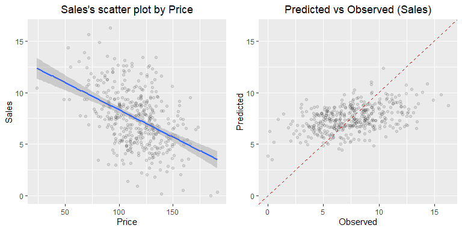

**[ Age ]**

Simple Linear Model Information

```
 Residual standard error: 3 on 398 degrees of freedom
 Multiple R-squared:  0.05374,  Adjusted R-squared:  0.05136
 F-statistic: 23 on 1 and 398 DF,  p-value: 2.78894983937141e-06
```

Coefficients:

Simple Linear Model coefficients : Age

|  | Estimate | Std. Error | t value | Pr(>\|t\|) |
| --- | --- | --- | --- | --- |
| (Intercept) | 9.65 | 0.47 | 20.38 | 0 |
| Age | -0.04 | 0.01 | -4.75 | 0 |

Visualization:

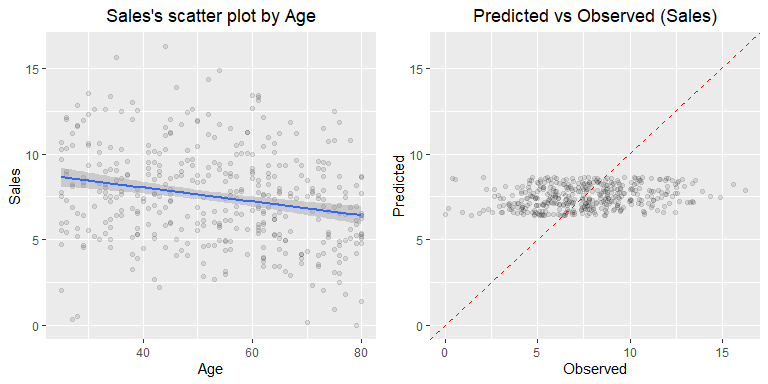

**[ Education ]**

Simple Linear Model Information

```
 Residual standard error: 3 on 398 degrees of freedom
 Multiple R-squared:  0.0027,   Adjusted R-squared:  0.00019
 F-statistic: 1 on 1 and 398 DF,  p-value: 0.299944152713169
```

Coefficients:

Simple Linear Model coefficients : Education

|  | Estimate | Std. Error | t value | Pr(>\|t\|) |
| --- | --- | --- | --- | --- |
| (Intercept) | 8.27 | 0.76 | 10.84 | 0.0 |
| Education | -0.06 | 0.05 | -1.04 | 0.3 |

Visualization:

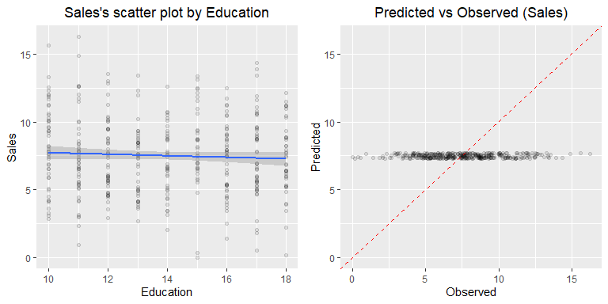

### 4.1.2 Grouped Categorical Variables

**[ ShelveLoc ]**  
1. Analysis of Variance

Analysis of Variance Table : ShelveLoc

|  | Df | Sum.Sq | Mean.Sq | F.value | Pr..F. |
| --- | --- | --- | --- | --- | --- |
| ShelveLoc | 2 | 1009.53 | 504.77 | 92.23 | 0 |
| Residuals | 397 | 2172.74 | 5.47 | NA | NA |

2. Simple Linear Model Information

Residual standard error: 2 on 397 degrees of freedom Multiple R-squared: 0.31724, Adjusted R-squared: 0.3138 F-statistic: 92 on 2 and 397 DF, p-value: 2.67871168766164e-34

Coefficients:

Simple Linear Model coefficients : ShelveLoc

|  | Estimate | Std. Error | t value | Pr(>\|t\|) |
| --- | --- | --- | --- | --- |
| (Intercept) | 5.52 | 0.24 | 23.13 | 0 |
| ShelveLocGood | 4.69 | 0.35 | 13.46 | 0 |
| ShelveLocMedium | 1.78 | 0.29 | 6.23 | 0 |

3. Visualization:

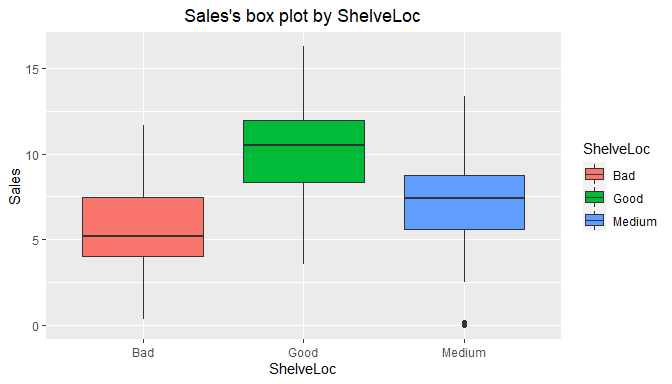

**[ Urban ]**  
1. Analysis of Variance

Analysis of Variance Table : Urban

|  | Df | Sum.Sq | Mean.Sq | F.value | Pr..F. |
| --- | --- | --- | --- | --- | --- |
| Urban | 1 | 0.03 | 0.03 | 0 | 0.96 |
| Residuals | 388 | 3107.21 | 8.01 | NA | NA |

2. Simple Linear Model Information

Residual standard error: 3 on 388 degrees of freedom Multiple R-squared: 1e-05, Adjusted R-squared: -0.00257 F-statistic: 0 on 1 and 388 DF, p-value: 0.955270569159221

Coefficients:

Simple Linear Model coefficients : Urban

|  | Estimate | Std. Error | t value | Pr(>\|t\|) |
| --- | --- | --- | --- | --- |
| (Intercept) | 7.52 | 0.26 | 28.51 | 0.00 |
| UrbanYes | -0.02 | 0.31 | -0.06 | 0.96 |

3. Visualization:

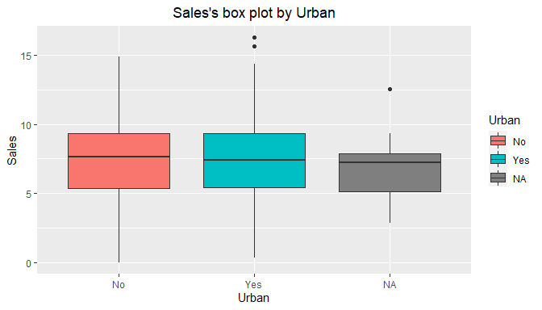

**[ US ]**  
1. Analysis of Variance

Analysis of Variance Table : US

|  | Df | Sum.Sq | Mean.Sq | F.value | Pr..F. |
| --- | --- | --- | --- | --- | --- |
| US | 1 | 99.80 | 99.80 | 12.89 | 0 |
| Residuals | 398 | 3082.47 | 7.74 | NA | NA |

2. Simple Linear Model Information

Residual standard error: 3 on 398 degrees of freedom Multiple R-squared: 0.03136, Adjusted R-squared: 0.02893 F-statistic: 13 on 1 and 398 DF, p-value: 0.000372339587014733

Coefficients:

Simple Linear Model coefficients : US

|  | Estimate | Std. Error | t value | Pr(>\|t\|) |
| --- | --- | --- | --- | --- |
| (Intercept) | 6.82 | 0.23 | 29.22 | 0 |
| USYes | 1.04 | 0.29 | 3.59 | 0 |

3. Visualization:

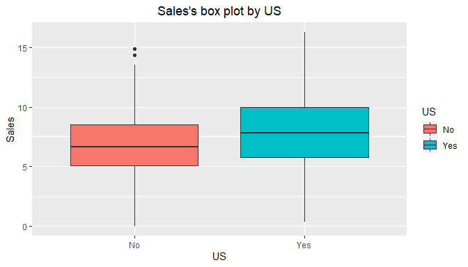

## 4.2 Grouped Relationship Between Variables

### 4.2.1 Grouped Correlation Coefficient

```
Numerical target variables are not supported.
```

### 4.2.2 Grouped Correlation Plot of Numerical Variables

```
Numerical target variables are not supported.
```